# Homework 2 Solutions

September 13, 2016

# Data

In this assignment you will manipulate a data frame, by taking subsets and creating new variables, with the goal of creating a plot.

You will work with a dataset called Baseball in the R library. The Baseball dataset describes baseball players’ stats from the ’86 and ’87 season, as well as career stats.

Before beginning with the housing data however, you will do some warm up exercises with the small family data set that we have used in class.

# Exercises

## Part 1: Family Data

Load the data from the Web into your R session with the following command:

```r
load(url("http://courseweb.lis.illinois.edu/~jguo24/family.rda"))
```

In the following exercises try to write your code to be as general as possible so that it could still work if the family had 27 members in it or if the variables were in a different order in the data frame.

#### Q1. *(2 pts.)*

The NHANES survey (the source of the family data) used different cut-off values for men and women when classifying them as over weight. Suppose that a man is classified as obese if his bmi exceeds 26 and a woman is classified as obese if her bmi exceeds 25.

Write a logical expression to create a logical vector, called OW_NHANES, that is TRUE if a member of family is obese and FALSE otherwise

```r
# We want [male AND bmi>26] OR [female AND bmi > 25]
OW_NHANES <- ifelse((family$gender=='m'&family$bmi>26)|(family$gender=='f'&family$bmi>25),TRUE,FALSE)
OW_NHANES
```

```
##  [1] FALSE FALSE FALSE FALSE FALSE  TRUE  TRUE FALSE  TRUE  TRUE  TRUE
## [12] FALSE FALSE FALSE
```

#### Q2. *(4 pts.)*

Here is an alternative way to create the same vector that introduces some useful functions and ideas

We will begin by creating a numeric vector called OW_limit that is 26 for each male in the family and 25 for each female in the family.

To do this, first create a vector of length 2 called OWval whose first element is 26 and second element is 25.

Create the OW_limit vector by subsetting OWval by position, where the positions are the numeric values in the gender variable (i.e. use as.numeric to coerce the factor vector to a numeric vector)

Finally, us OW_limit and bmi to create the desired logical vector, and call it OW_NHANES2.

```r
OWval <- c(26,25)
OW_limit <- OWval[as.numeric(family$gender)]
OW_NHANES2 <- family$bmi > OW_limit
OW_NHANES2
```

```
##  [1] FALSE FALSE FALSE FALSE FALSE  TRUE  TRUE FALSE  TRUE  TRUE  TRUE
## [12] FALSE FALSE FALSE
```

```r
# Confirm the vectors are identical (all() returns true if every condition is TRUE)
all(OW_NHANES==OW_NHANES2)
```

```
## [1] TRUE
```

#### Q3. *(2 pts.)*

Use the vector OW_limit and each person’s height to find the weight that they would have if their bmi was right at the limit (26 for men and 25 for women). Call this weight OW_weight

To do this, start with the formula: bmi = (weight/2.2) / (2.54/100 * height)^2 and find re-express it in terms of weight.

Make a plot of the weight at wihich they would be over weight aginst actual weight

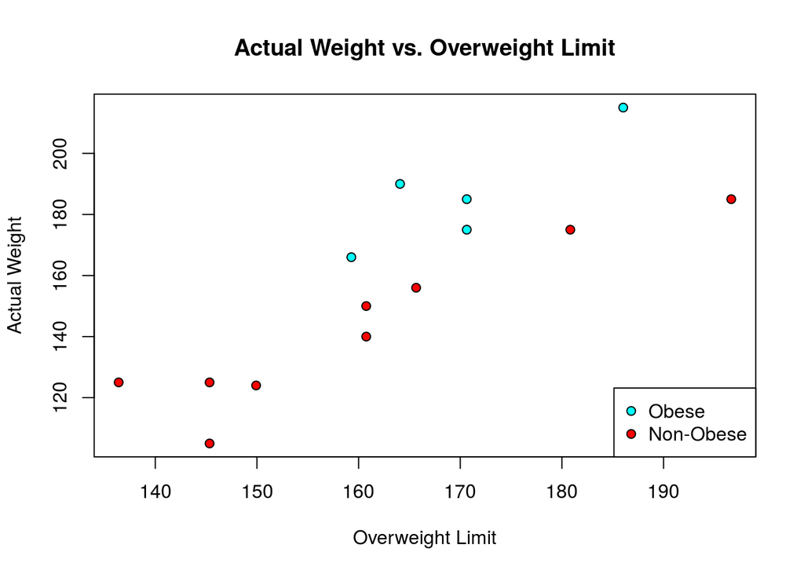

```r
OW_weight <-  (OW_limit * (2.54/100 * family$height)^2) * 2.2
plot(OW_weight,family$weight,ylab="Actual Weight",xlab="Overweight Limit",main="Actual Weight vs. Overweight Limit",bg=rainbow(2)[OW_NHANES+1],pch=c(21,21))
legend(x="bottomright",pt.bg=c(rainbow(2)[2],rainbow(2)[1]),pch=21,legend=c("Obese","Non-Obese"))
```

## Part 2: Baseball Data

Load the data into R. In order to access this data set we will install the relevant package and use the following code to do so:

```r
#install.packages("vcd")
library(vcd)
attach(Baseball)

# Can also use
data(Baseball)
```

This means that the dataset Baseball was in the vcd package.

#### Q4. *(4 pts.)*

How many variables are in the dataset Baseball?

```r
cols <- ncol(Baseball)
```

There are 25 variables in the Baseball dataset.

How many observations are in Baseball?

```r
rows <- nrow(Baseball)
```

There are 322 observations in Baseball.

For a more DETAILED description of ALL of the variables is this data set, visit: https://vincentarelbundock.github.io/Rdatasets/doc/vcd/Baseball.html

Run the summary function and anwser the following questions: For the variable team87, which state had the most baseball players in the dataset?

```r
summary(Baseball$team87)
```

```
## Atl Bal Bos Cal Chi Cin Cle Det Hou  KC  LA Mil Min Mon  NY Oak Phi Pit
##  12  15  11  12  22  11  13  13  12  14  13  14  14  13  24  13  13  16
##  SD  SF Sea StL Tex Tor
##  10  15  11   9  12  10
```

Make an observation about the variable, sal87, which is the yearly salary of the selected baseball players in the dataset.

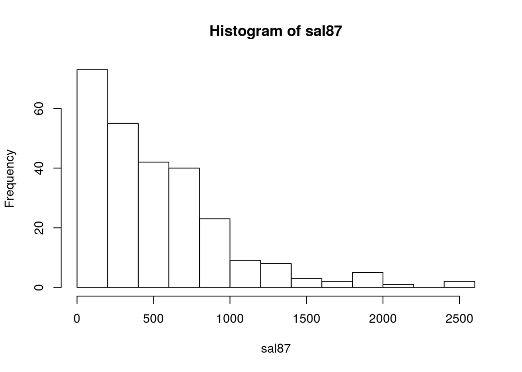

```r
hist(sal87)
```

Most of the players tend to be on the lower end of the pay scale.

Who is the highest paid player in the data set?

```r
index <- which.max(Baseball$sal87)
name <- paste(name1[index],name2[index])
```

The highest paid player is Eddie Murray.

#### Q5. *(2 pts.)*

Now, we only want to use the baseball players in the National League. This information is found through the variable, league86. The letter N indicates that the player is in the National League. The letter A indicates that the player is in the American League. Subset the new data frame so that all of the baseball players are in the National League, and only keep the following variables: name1, name2, years, hits86, homer86, homeruns,rbi, and sal87. To clarify, the variable, homer86 are the homeruns in that the player hit in ’86, and the variable homeruns are career homeruns for each player. Call the new data Baseball1 (your code below)

```r
Baseball1 <- Baseball[league86=="N",c("name1","name2","years","hits86","homer86","homeruns","rbi","sal87")]
head(Baseball1)
```

```
##     name1     name2 years hits86 homer86 homeruns rbi sal87
## 1      Al    Newman     2     37       1        1   9  70.0
## 2    Alan     Ashby    14     81       7       69 414 475.0
## 5    Alex   Trevino     9     53       4       15 186 512.5
## 8   Andre    Dawson    11    141      20      225 838 500.0
## 10 Andres Galarraga     2     87      10       12  46  91.5
## 11 Andres    Thomas     2     81       6        6  34  75.0
```

#### Q6. *(2 pts.)*

We want to remove unusually large values in order to further subset the data. Use the quantile function to determine the 99% of variable sal87 (the salaries of the players in ’87). Then remove those baseball players that are above the 99th percentile. Call this new dataset Baseball1 as well.

```r
quant <- quantile(Baseball1$sal87,0.99,na.rm = TRUE)
Baseball1 <- Baseball1[Baseball1$sal87<unname(quant),]
```

#### Q7. *(2 pts.)*

Create a new vector called hitsperhome. Divide hits86 by homer86, and this will create our new vector. Now add this new variable to the data frame.

```r
Baseball1$hitsperhome <- Baseball1$hits86/Baseball1$homer86
```

#### Q8. *(2 pts.)*

Create a vector called hr15, this will be the number of homeruns hit in the year 1986 (NOT total) so use the variable, homer86, if this number is greater than 15, it is set to 15. So if a player has 15 or more homeruns in that year, then hr15 will be 15, otherwise it will be the actual number of homeruns.

```r
hr15 <- ifelse(Baseball1$homer86>15,15,Baseball1$homer86)
```

#### Q9. *(2 pts.)*

Find out if there is a significant association between homeruns hit in 1986, variable homer86, and the salary of the players on opening day in 1987, variable sal87 (which is USD 1000). Answer this using several functions, including the plot function. Make 3 observations below.

```r
# Example functions
model <- lm(sal87~homer86,data=Baseball1)
summary(model)
```

```
##
## Call:
## lm(formula = sal87 ~ homer86, data = Baseball1)
##
## Residuals:
##     Min      1Q  Median      3Q     Max
## -805.48 -251.56  -43.98  216.38 1215.87
##
## Coefficients:
##             Estimate Std. Error t value Pr(>|t|)
## (Intercept)  268.991     53.647   5.014 1.86e-06 ***
## homer86       24.242      4.424   5.479 2.39e-07 ***
## ---
## Signif. codes:  0 '***' 0.001 '**' 0.01 '*' 0.05 '.' 0.1 ' ' 1
##
## Residual standard error: 354.7 on 120 degrees of freedom
##   (23 observations deleted due to missingness)
## Multiple R-squared:  0.2001, Adjusted R-squared:  0.1935
## F-statistic: 30.02 on 1 and 120 DF,  p-value: 2.392e-07
```

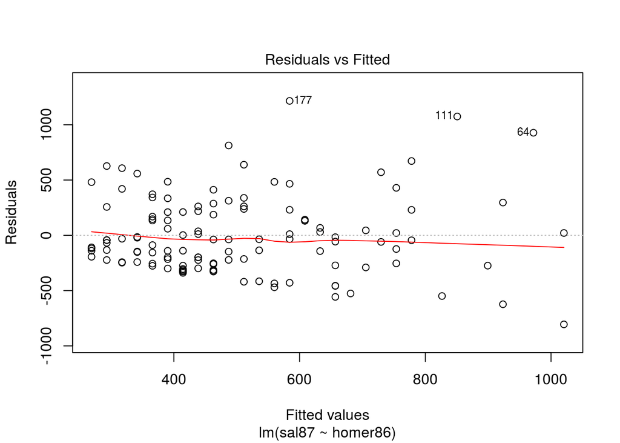

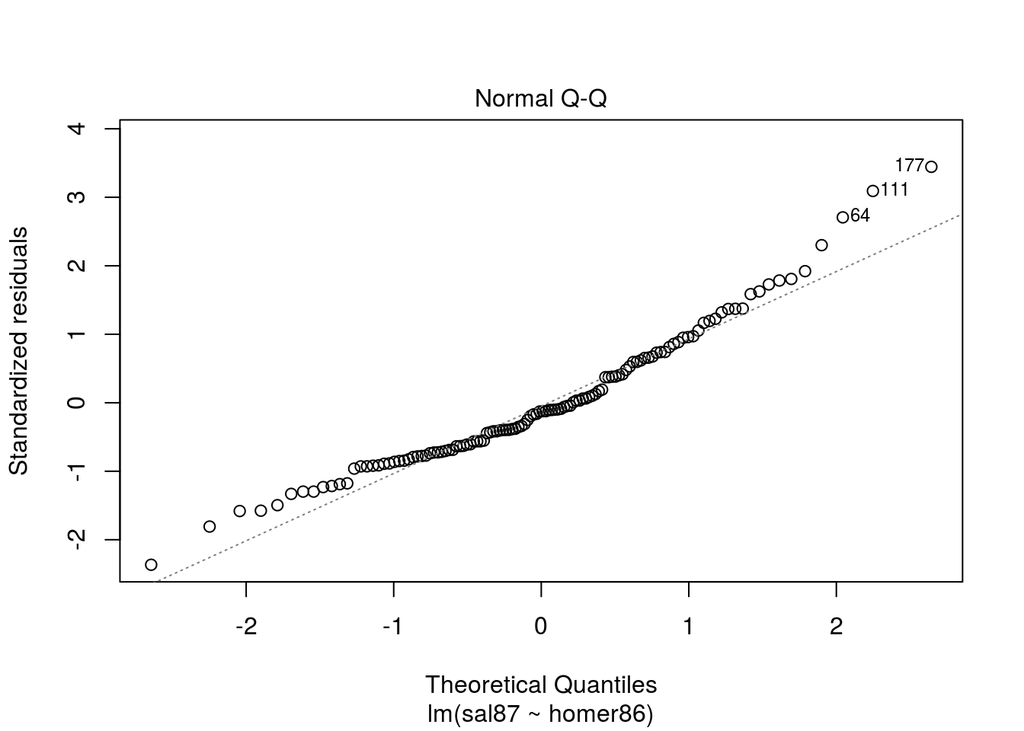

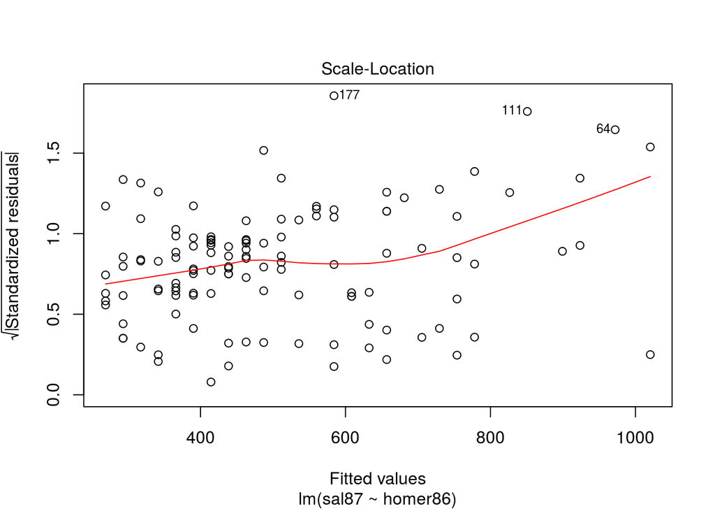

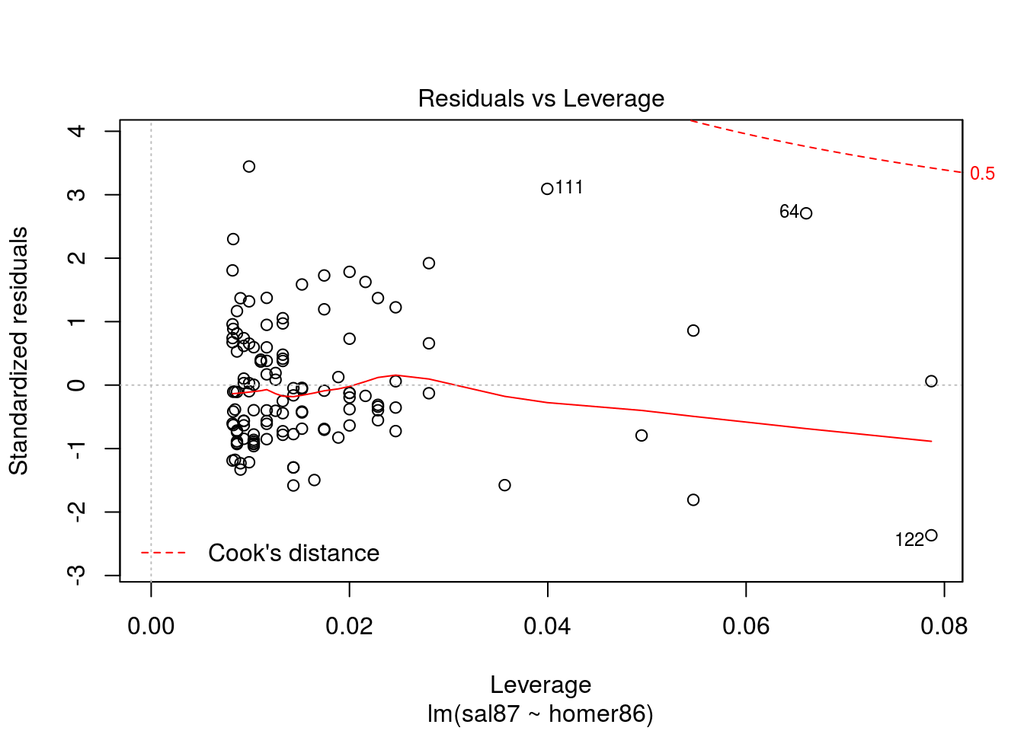

```r
plot(model)
```

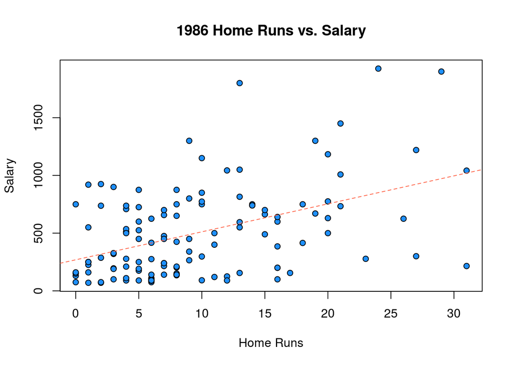

```r
plot(Baseball1$homer86,Baseball1$sal87,main="1986 Home Runs vs. Salary",xlab="Home Runs",ylab="Salary",pch=21,bg="dodgerblue")
abline(model,lty="dashed",col="tomato")
```

```r
correlation <- cor(Baseball1$homer86,Baseball1$sal87,use="pairwise.complete.obs")
```

Example observations: There appears to be a weak relationship:

- The correlation between the two variables is 0.4473575.
- The diagnostic plots of the regression model are decent at best.
- While the regression coefficient is statistically significant, the $R^2$ value is quite low.